# Part II - Prosper Loan Exploration

## by Rashidat Sikiru

## Investigation Overview

In this investigation, I wanted to look at the factors or features that could help the loan applicant to get the approval status. The main focus was on the some of the variables like 'Term' , 'LoanStatus', 'BorrowerRate' , 'ProsperScore', 'EmploymentStatus', 'Occupation', 'BorrowerHomeowner', 'StatedMonthlyIncome', 'Recommendations', 'LoanOriginalAmount' , 'IncomeRange'.

## Dataset Overview

This ProsperLoan data set contains 113,937 loans with 81 variables on each loan, including loan amount, borrower rate (or interest rate), current loan status, borrower income, and many others.

For simplicity of the visualization I have looked at only few variables as the project objective itself says to focus on only few variables.

## (Visualization 1)

This first visualisation shows the occupation of borrowers and it can be seen clearly that people with other occcupation not listed are likely to request for loans. Also professionals and computer programmers have high potential of reqesting for loans

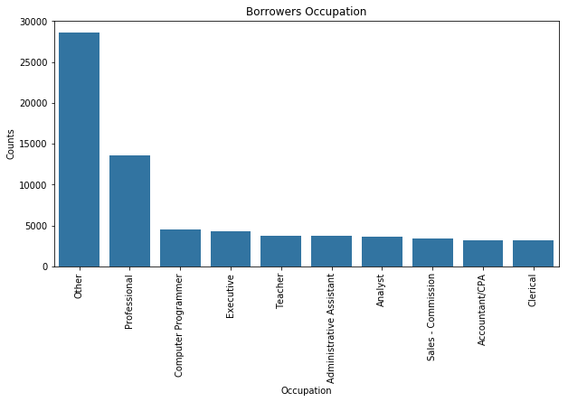

## (Visualization 2)

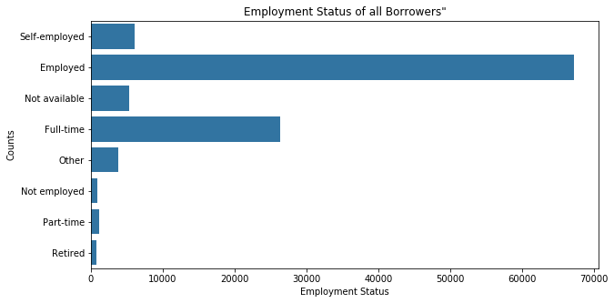

## (Visualization 3)

This visalisation shows the top 10 borrowing state in the US. This visualisation shows that Carlifornia is the state that has individuals that borros most followed bt Texas. We Can categorically say that we have more borroin in these states as a results of their population

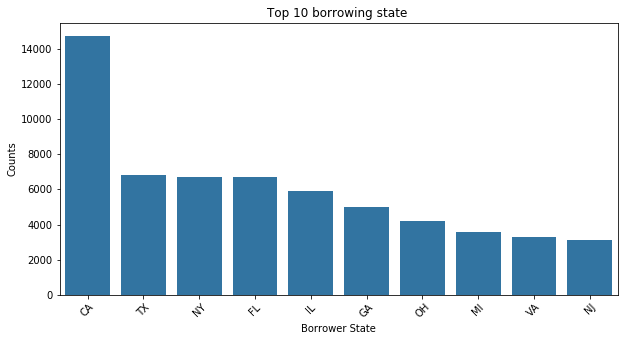